# Data visualization

Let's focus on some important variables

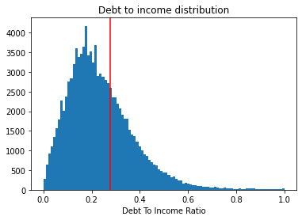

```python
plt.hist(df.DebtToIncomeRatio,bins =np.linspace(0,1,100))
plt.axvline(x=df.DebtToIncomeRatio.mean(), color = 'r');
plt.title('Debt to income distribution')
plt.ylabel('count of loans')

plt.xlabel('Debt To Income Ratio');
```

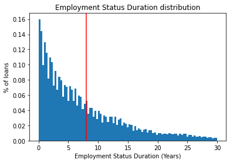

```python
plt.hist(df.EmploymentStatusDuration/12,bins = np.linspace(0,30,100),density  = True );
plt.title('Employment Status Duration distribution')
plt.axvline(x=df.EmploymentStatusDuration.mean()/12, color = 'r')
plt.ylabel('% of loans')

plt.xlabel('Employment Status Duration (Years)');
```

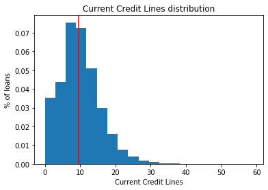

```python
plt.hist(df.CurrentCreditLines,bins = 20,density  = True )
plt.title('Current Credit Lines distribution')
plt.axvline(x=df.CurrentCreditLines.mean(), color = 'r')
plt.ylabel('% of loans')

plt.xlabel('Current Credit Lines');
```

Amount of credit lines is right skewed with average of 10 lines

# What happened after 2008 ?

The financial crises happened in 2008, laons defaulted was one of the key factors that caused the crises, what happened before and after 2008, the following charts show the trends of the # of loans , sum of loans and borrower rate per year

*Loan Amount in M$ (red line) Vs Count of loans (blue line) over the years*

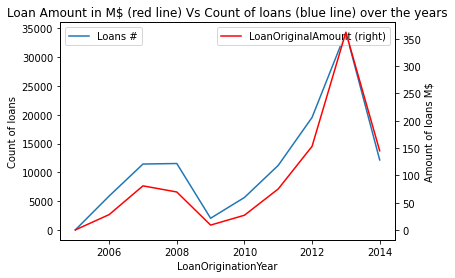

```python
ax = df.groupby(['LoanOriginationYear']).count().max(axis = 1).plot.line()
ax1 = ax.twinx()
(df.groupby(['LoanOriginationYear']).sum()[['LoanOriginalAmount']]/1000000).plot.line(ax=ax1, color='r',secondary_y=True)
plt.xlabel('Year')
plt.title('Loan Amount in M$ (red line) Vs Count of loans (blue line) over the years')

plt.ylabel('Amount of loans M$')
ax.legend(['Loans #','Loan M$'])
ax.set_ylabel('Count of loans');
```

as shown in the graph above, after 2008 there was a sharp decline in # of loans and the amount of money lended, then a ste increase in both metircs, reaching the maximum by 2013.

*Loan Rate % over the years*

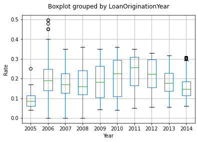

```python
df.boxplot(by="LoanOriginationYear", column="BorrowerRate")
plt.ylabel('Rate')
plt.xlabel('Year')
plt.title('');
```

as shown in the graph above, after 2008 there was an increase in loan rate after 2008, which is expected, then it started to decline after 2011.

*Loan status over the years*

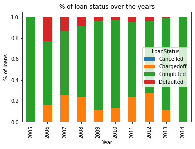

```python
closedLoans = df[~df['ClosedDate'].isna()]
time_bar(closedLoans,'LoanOriginationYear', 'LoanStatus' )
plt.title('% of loan status over the years')
plt.ylabel('% of loans')

plt.xlabel('Year');
```

Loan defaulted was the highest in 2006, started to decline sharply since 2009 with more completed loans, but what is the reason for that ? Let's see why people take loans at first place?

*Loan reason over the years*

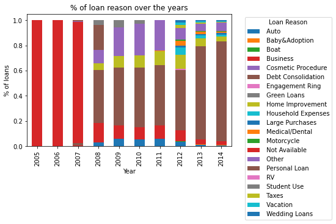

```python
time_bar(df,'LoanOriginationYear','loanreason')
plt.legend(title = 'Loan Reason', bbox_to_anchor=(1.05, 1), loc='upper left')
plt.title('% of loan reason over the years')
plt.ylabel('% of loans')

plt.xlabel('Year');
```

Well, there're alot of reasons, we can't see much, however, we can see debt consolidation category started to spike after 2008. let's focus a bit on that.

*% of debt consolidation over the years*

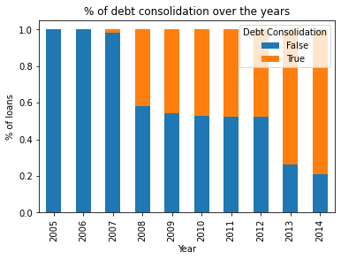

```python
df['isdebtcons'] = df['ListingCategory (numeric)'] == 1
time_bar(df,'LoanOriginationYear','isdebtcons')
plt.title('% of debt consolidation over the years')
plt.legend(title = 'Debt Consolidation')
plt.ylabel('% of loans')

plt.xlabel('Year');
```

As shown above, after 2008 the debt consolidation is the # 1 reason for asking for loans, by 2013 it represented around 80% of the # of loans. interesting, isn't it?

*# of debt consolidation loans over the years*

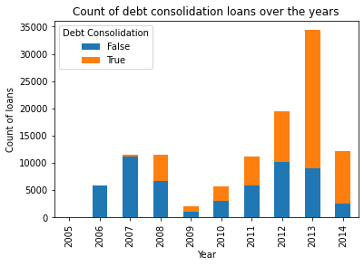

```python
time_bar(df,'LoanOriginationYear','isdebtcons',ispercent = False)
plt.legend(title = 'Debt Consolidation')
plt.title('Count of debt consolidation loans over the years')

plt.xlabel('Year')
plt.ylabel('Count of loans');
```

This graph shows that the increase in # of loans is actuall coming from the debt consolidation category.

**When people tend to take debt consolidation loan?**

**# of open credit lines hist**

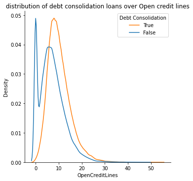

```
''
```

```python
sb.displot(df, x="OpenCreditLines", hue="isdebtcons", kind="kde",legend = False)
plt.legend(title='Debt Consolidation', loc='upper right', labels=['True', 'False'])
plt.title('distribution of debt consolidation loans over Open credit lines')

plt.show(g)
;
```

Non debt consolidation seems bi-modal, which make sense, people don't take loans because either they don't have open credit items or they don't like the idea.

**% of debt consolidation VS open credit lines**

[figure not shown]

```python
plt.figure(figsize =(5,40) );
ax = time_bar(df,'OpenCreditLines','isdebtcons',ispercent = True);
plt.legend(title='Debt Consolidation', loc='upper right', labels=['True', 'False'])
plt.xlabel('Open Credit Lines')
plt.title('% of debt consolidation loans over Open credit lines')
plt.ylabel('% of loans')

plt.xlim((-1,30));
```